# Infrastructure Investment & Jobs Act Funding Allocation

Kossi Akplaka

2024-02-04

## Introduction

The purpose of this data visualization analysis is to examine the allocation of funds across States and Territories in the United States. We will assess whether the allocation is equitable based on population and explore any potential biases favoring the political interests of the Biden administration.

## Data Analysis

Import Libraries for this analysis

```r
library(tidyverse)
library(knitr)
library(kableExtra)
```

### Data sources

- Present allocation of the IIJA by State and Territory:
- List of U.S states_and_territories_by_population as of April 2020 Census
- U.S. 2020 Presidential Election Results Per State

I merge the files in Excel and upload the data on GitHub.

### Data Exploration

Import the data from GitHub

```r
allocation_df <- as.data.frame(read.csv("https://raw.githubusercontent.com/Kossi-Akplaka/Data608-Visualization/main/Story%201/IIJA%20FUNDING%20DATA.csv"))
kable(head(allocation_df,5), "html") %>%
  kable_styling(bootstrap_options = "striped", full_width = T)
```

| State_Teritory_Tribal_Nation | Allocation | Population | Election_Winner |
| --- | --- | --- | --- |
| ALABAMA | 3.0000 | 5024279 | Republican |
| ALASKA | 3.7000 | 733391 | Republican |
| AMERICAN SAMOA | 0.0686 | 49710 | No electoral Vote |
| ARIZONA | 3.5000 | 7151502 | Democrat |
| ARKANSAS | 2.8000 | 3011524 | Republican |

Let’s visualize the data to examine whether the allocation is equitable based on population.

### Population vs. Allocation Comparison

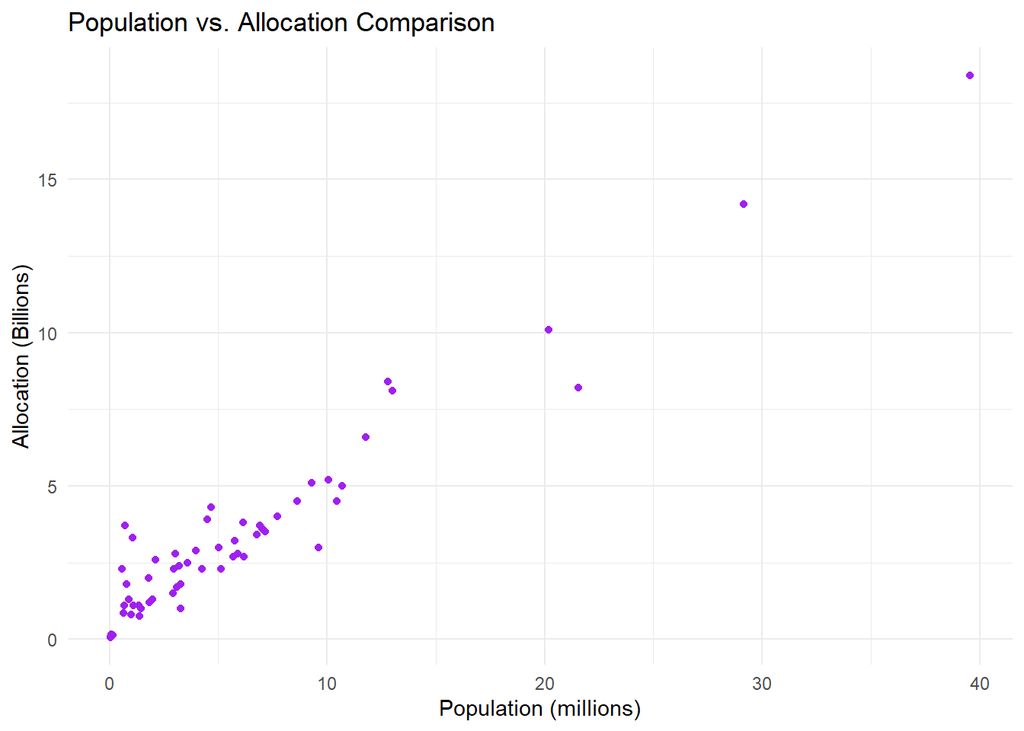

```r
allocation_df$Population_millions <- as.numeric(allocation_df$Population) / 1e6

ggplot(allocation_df, aes(x = Population_millions , y = Allocation )) +
  geom_point(color = 'Purple') +
  labs(title = "Population vs. Allocation Comparison",
       x = "Population (millions)",
       y = "Allocation (Billions)") +
  theme_minimal()
```

Based on the above scatter plot, there is a general trend of proportionality between the population size and allocation of IIJA funds for states and territories. However, notable deviations from this trend are observed, with certain states or territories receiving allocations that either exceed or fall short of what would be expected based solely on their population size.

These variations suggest that factors beyond population alone may influence the allocation of IIJA funds

### Per Capita Allocation

Let’s take a closer look on the per capita allocation of funds for each State and Territory.

```r
# Calculate the fund allocation per capita
allocation_df$Per_capita <- round((as.numeric(allocation_df$Allocation)*1e9)/(as.numeric(allocation_df$Population)))

head(allocation_df$Per_capita)
```

```
## [1]  597 5045 1380  489  930  465
```

Plot the Per Capita Allocation

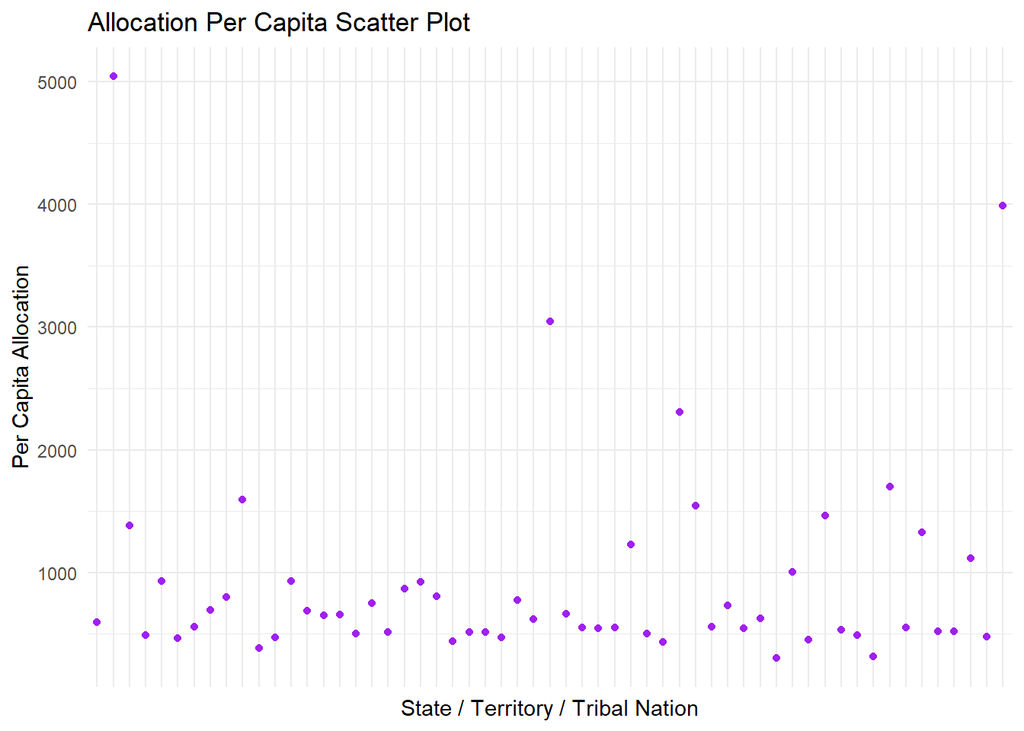

```r
ggplot(allocation_df, aes(x = State_Teritory_Tribal_Nation, y = Per_capita)) +
  geom_point(color = 'purple') +
  labs(title = "Allocation Per Capita Scatter Plot",
       x = "State / Territory / Tribal Nation",
       y = "Per Capita Allocation") +
  theme_minimal() +
  theme(axis.text.x = element_blank())
```

Ideally, Per Capita Allocation should be relatively consistent across different states and territories to ensure equitable distribution of resources.

Let’s explore the other factors that can lead to variations in Per Capita Allocation

### Biases favoring the political interests of the Biden administration

Let’s create a scatter plot comparing Per Capita Allocation for states won by Republican and Democrat candidates in the 2020 election

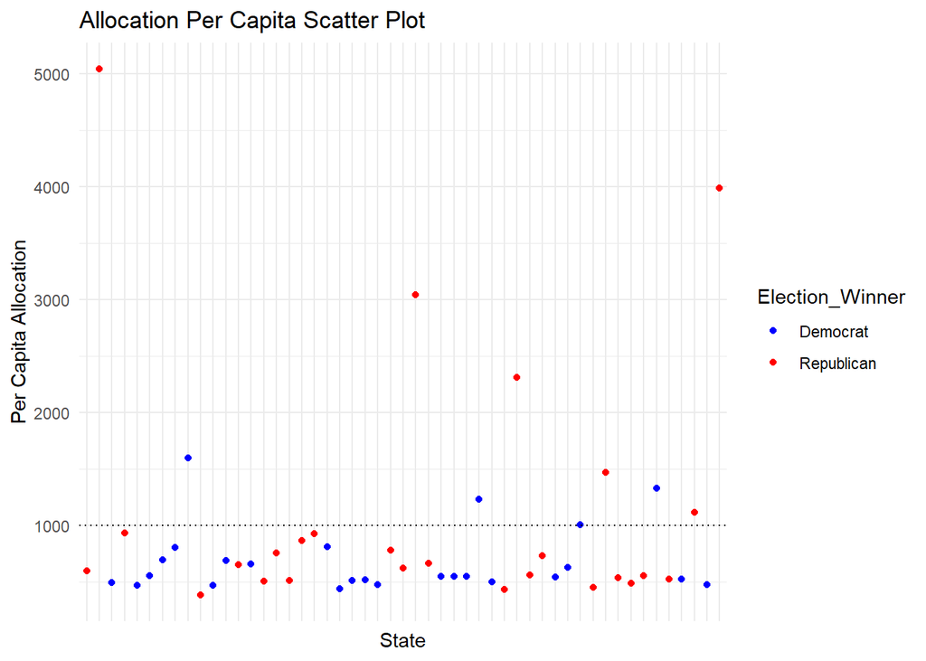

```r
State_Allocation <- allocation_df %>%
  filter(Election_Winner == 'Republican'| Election_Winner == 'Democrat')

ggplot(State_Allocation, aes(x = State_Teritory_Tribal_Nation, y = Per_capita, color = Election_Winner)) +
  scale_color_manual(values = c("Republican" = "red", "Democrat" = "blue"))+
  geom_point() +
  labs(title = "Allocation Per Capita Scatter Plot",
       x = "State",
       y = "Per Capita Allocation") +
  geom_hline(yintercept = 1000, linetype = "dotted", color = "black")+
  theme_minimal() +
  theme(axis.text.x = element_blank())
```

### Summary Statistics

Let’s create a table of the minimum, maximum, and average Per Capita Allocation for Republican and Democrat states.

```r
State_Allocation %>%
  group_by(Election_Winner) %>%
  summarise(
    Min_PerCapita = min(Per_capita),
    Max_PerCapita = max(Per_capita),
    Avg_PerCapita = round(mean(Per_capita))
  ) %>%
  bind_rows(
    State_Allocation %>%
      summarise(
        Election_Winner = "Overall",
        Min_PerCapita = min(Per_capita),
        Max_PerCapita = max(Per_capita),
        Avg_PerCapita = round(mean(Per_capita))
      )
  ) %>%
  kable("html") %>%
  kable_styling(bootstrap_options = "striped", full_width = T)
```

| Election_Winner | Min_PerCapita | Max_PerCapita | Avg_PerCapita |
| --- | --- | --- | --- |
| Democrat | 437 | 1595 | 680 |
| Republican | 381 | 5045 | 1131 |
| Overall | 381 | 5045 | 910 |

The table clearly illustrates that, on average, Republican states received a higher Per Capita Allocation compared to Democrat states. This observation emphasizes that there is no apparent bias of Biden administration in the allocation process.

Create a table that includes counts for both the number of states above and below the average Per Capita Allocation

```r
# Average Per capita allocation
average_allocation <- mean(State_Allocation$Per_capita)
# summary table
State_Allocation %>%
  mutate(Above_Avg = Per_capita > average_allocation) %>%
  group_by(Election_Winner) %>%
  summarise(
    Total_Count = n(),
    Above_Avg_Count = sum(Above_Avg),
    Below_Avg_Count = Total_Count - Above_Avg_Count
  ) %>%
  select (Election_Winner, Above_Avg_Count, Below_Avg_Count) %>%
  kable("html") %>%
  kable_styling(bootstrap_options = "striped", full_width = T)
```

| Election_Winner | Above_Avg_Count | Below_Avg_Count |
| --- | --- | --- |
| Democrat | 4 | 21 |
| Republican | 8 | 18 |

## Conclusion

The purpose of this story is to assess whether the allocation is equitable based on population and explore any potential biases favoring the political interests of the Biden administration.

- Although the biggest factors for allocation is the population, there are others factors influencing funds allocations. This led to variation in the per capita Allocation.
- There is no evidence of potential biases favoring the political interests of the Biden administration. In contrary, states won by Republican party in 2020 saw a higher allocation on average.